# Проверка гипотез. Классические статистические тесты

Автор

Киренская Валерия

# Требования к сдаче и оформлению задания

Заполните этот qmd-файл кодом и текстовыми ответами. Порядок сдачи задания описан в `README.md`. Требования ниже действуют для всех заданий, даже если в отдельном пункте они не повторяются.

1. Соблюдайте единый стиль оформления и структуру отчёта. Не оставляйте лишние блоки кода, текст или комментарии, которые не относятся к решению задания.
2. Ответы на вопросы, обоснования выбора методов и интерпретации результатов пишите обычным текстом, а не комментариями к коду. Код и его вывод, таблицы и графики не заменяют ответ на вопрос. Замените заглушки `*(ответ студента)*` своими ответами.
3. Численные результаты представляйте в тексте или аккуратных таблицах с понятными подписями. Не оставляйте необработанный консольный вывод или отдельные числа без пояснений. Допускается сохранять стандартный вывод функций статистических тестов, но его необходимо сопровождать текстовой интерпретацией.
4. После каждой проверки гипотезы сформулируйте текстовый вывод: укажите p-значение, уровень значимости и решение об отклонении или неотклонении нулевой гипотезы. Ответьте на исследовательский вопрос. Если в задании требуется доверительный интервал, объясните его смысл. Различайте статистическую и практическую (клиническую) значимость эффекта.
5. Графики должны быть достаточно крупными, с читаемыми русскими подписями, содержательным заголовком и правильно названными осями. Где применимо, указывайте единицы измерения. Не используйте фон ggplot2 по умолчанию.
6. Сохраняйте исходную структуру проекта в репозитории. Не добавляйте лишние файлы, которые не относятся к проекту или выполнению заданий.
7. Оформление коммитов и веток на GitHub должно соответствовать общим правилам для всех курсов Института биоинформатики.

# Настройка

Загрузите необходимые пакеты и установите seed.

```r
library(tidyverse)
library(ggplot2)
library(flextable)
library(knitr)
set.seed(seed = 42)
```

## Загрузка и проверка данных

В этом упражнении мы будем использовать данные NHANES (Национальное обследование здоровья и питания населения США). Подробное описание исходного набора данных и его переменных: [документация NHANES](https://cran.r-project.org/web/packages/NHANES/refman/NHANES.html).

Прочитайте предоставленный файл с данными.

```r
df_raw <- read_csv("data/nhanes.csv")
```

Проверьте размер и структуру таблицы, типы переменных и наличие пропущенных значений. Убедитесь, что данные прочитаны корректно.

Подготовьте данные для выполнения заданий:

1. Оставьте столбцы `ID`, `Gender`, `Age`, `BMI`, `BPSysAve`, `BPDiaAve`, `PhysActive`, `SleepTrouble`, `Height`, `Weight`, `Education` и `HHIncome`.
2. Оставьте только участников в возрасте 18 лет и старше.
3. Для простоты задания удалите строки, в которых есть хотя бы одно пропущенное значение среди оставленных столбцов.
4. Проверьте типы переменных и при необходимости преобразуйте их. Для порядковых признаков убедитесь, что порядок категорий соответствует их смыслу, а не алфавитному порядку.

Сохраните подготовленную таблицу в объект `nhanes_clean`. Сколько строк было до подготовки и сколько осталось после неё?

```r
nhanes_clean <- df_raw |>
  select(ID, Gender, Age, BMI, BPSysAve, BPDiaAve, PhysActive, SleepTrouble, Height, Weight, Education, HHIncome) |>
  filter(Age >= 18) |>
  na.omit()

nhanes_clean <- nhanes_clean |> mutate(
  Gender = factor(x = Gender, levels = c("male", "female")),
  PhysActive = factor(x = PhysActive, levels = c("Yes", "No")),
  SleepTrouble = factor(x = SleepTrouble, levels = c("Yes", "No")),
  Education = factor(x = Education, levels = c("8th Grade", "9 - 11th Grade", "High School", "Some College",
  "College Grad"), ordered = TRUE),
  HHIncome = factor(x = HHIncome, levels = c("0-4999", "5000-9999", "10000-14999", "15000-19999", "20000-24999",
  "25000-34999", "35000-44999", "45000-54999", "55000-64999", "65000-74999","75000-99999", "more 99999"), ordered = TRUE)
)

nrow(df_raw)
```

```
[1] 6779
```

```r
nrow(nhanes_clean)
```

```
[1] 4032
```

До фильтрации пропущенных значений было 6779 опрошенных жителей USA, после фильтрации их осталось 4032

# Тесты для непрерывных данных

## Параметрические тесты

### 1. Сравнение ИМТ с историческим средним

На основе исторических данных среднее значение ИМТ (`BMI`) для взрослых в США составляет **28.5**. ИМТ (индекс массы тела) рассчитывается как масса в килограммах, делённая на квадрат роста в метрах: $\mathrm{ИМТ} = \text{масса (кг)} / \text{рост (м)}^2$. Вопрос исследования: отличается ли среднее значение ИМТ в популяции взрослых (возраст ≥ 18) от исторического значения **28.5**?

#### Задание 1.1

Сформулируйте нулевую и альтернативную гипотезы.

- $H_0$: $\mu = 28.5$ - Среднее значение ИМТ в популяции взрослых равно историческому значению
- $H_a$: $\mu \neq 28.5$ - Среднее значение ИМТ в популяции взрослых не равно историческому значению

#### Задание 1.2

Посчитайте ключевые статистики (среднее, стандартное отклонение, размер выборки) для переменной `BMI` в вашем чистом наборе данных `nhanes_clean`.

```r
bmi_stats <- nhanes_clean |> summarise(
  mean = mean(BMI),
  sd = sd(BMI),
  sample_size = n())

bmi_stats
```

```
# A tibble: 1 × 3
   mean    sd sample_size
  <dbl> <dbl>       <int>
1  29.0  6.85        4032
```

#### Задание 1.3

Выберите подходящий статистический тест для проверки гипотез из задания 1.1 и объясните свой выбор.

В данном исследовании я буду использовать одновыборочный t-критерий Стьюдента для сравнения выборочного среднего с известным средним 28.5. Допущения данного статистического теста должны быть выполнены, так как размер выборки достаточно большой (будет работать ЦПТ для распределения выборочного среднего), признак количественный, непрерывный и наблюдения независимы.

#### Задание 1.4

Используя выбранный тест, проверьте гипотезы из задания 1.1 на уровне значимости α = 0.1.

```r
mu_0_bmi <- 28.5
t.test(nhanes_clean$BMI, mu = mu_0_bmi, conf.level = 0.9)
```

```
    One Sample t-test

data:  nhanes_clean$BMI
t = 4.5709, df = 4031, p-value = 5.003e-06
alternative hypothesis: true mean is not equal to 28.5
90 percent confidence interval:
 28.81560 29.17056
sample estimates:
mean of x
 28.99308
```

### 2. Сравнение давления у мужчин и женщин

Сценарий: Исследователи хотят сравнить систолическое артериальное давление у мужчин и женщин. Вопрос исследования: есть ли статистически значимая разница в среднем систолическом артериальном давлении (`BPSysAve`) между **мужчинами** и **женщинами**?

#### Задание 2.1

Сформулируйте нулевую и альтернативную гипотезы.

- $H_0$: $\mu_{male} = \mu_{female}$ - Средние значения систолического артериального давления равны
- $H_a$: $\mu_{male} \neq \mu_{female}$ - Средние значения систолического артериального давления не равны

Подумайте, имеет ли значение, в какой группе давление больше.

Нет, не имеет. В нашем случае разница средних может быть сдвинута в любую сторону от 0, чтобы дать основание для отвержения нулевой гипотезы.

#### Задание 2.2

Посчитайте ключевые статистики (среднее в каждой группе, стандартное отклонение, размер каждой группы) для переменной `BPSysAve` в вашем чистом наборе данных `nhanes_clean`. Группы определяются переменной `Gender`.

```r
nhanes_clean |>
  group_by(Gender) |>
  summarise(
    mean = mean(BPSysAve),
    sd = sd(BPSysAve),
    sample_size = n()
  )
```

```
# A tibble: 2 × 4
  Gender  mean    sd sample_size
  <fct>  <dbl> <dbl>       <int>
1 male    123.  15.9        1983
2 female  119.  18.3        2049
```

#### Задание 2.3

Выберите подходящий статистический тест для проверки гипотез из задания 2.1 и объясните свой выбор.

В данном исследовании я буду использовать двухвыборочный t-критерий Уэлча, так как группы независимые и имеют разное количество наблюдений. Также критерий Уэлча не требует равенства дисперсий, мы видим, что у групп разные дисперсии у исследуемого признака BPSysAve (однако мы не имеет данных о дисперсиях во всей генеральной совокупности).

#### Задание 2.4

Используя выбранный тест, проверьте гипотезы из задания 2.1 на уровне значимости α = 0.1.

```r
alpha = 0.1
t.test(BPSysAve ~ Gender, data = nhanes_clean, conf.level = 1 - alpha)
```

```
    Welch Two Sample t-test

data:  BPSysAve by Gender
t = 7.7246, df = 3983.3, p-value = 1.41e-14
alternative hypothesis: true difference in means between group male and group female is not equal to 0
90 percent confidence interval:
 3.275257 5.047990
sample estimates:
  mean in group male mean in group female
            123.3359             119.1742
```

#### Задание 2.5

Как p-значение и 90% доверительный интервал информируют вас о разнице измеренного артериального давления между мужчинами и женщинами? Что вы можете сказать про статистическую значимость?

В соответствии с результатом статистического теста с уровнем значимости 0.1 значение p.value равно 1.41e-14, а 90% доверительный интервал равен (3.275257-5.047990). Значение p.value < 0.1, а доверительный интервал не захватывает 0, исходя из этого мы можем сделать вывод о том, что разница средних не равна 0 и различие статистически значимо. Мы отвергаем нулевую гипотезу и принимаем альтернативную гипотезу о том, что измеренное артериальное давление различается между мужчинами и женщинами в USA. Кроме того, по полученным результатам можно сделать вывод о том, что среднее значение систолического артериального давления больше у мужчин.

### 3. Сравнение систолического и диастолического давления

Сценарий: Измерения систолического (`BPSysAve`) и диастолического (`BPDiaAve`) давления не являются независимыми. Вопрос исследования: равна ли нулю средняя **разница** между систолическим (`BPSysAve`) и диастолическим (`BPDiaAve`) давлением (пульсовое давление) в исследуемой популяции?

#### Задание 3.1

Сформулируйте нулевую и альтернативную гипотезы.

- $H_0$: $\mu_{(BPSysAve - BPDiaAve)} = 0$
- $H_a$: $\mu_{(BPSysAve - BPDiaAve)} \neq 0$

Подумайте, имеет ли значение, в какой группе давление больше.

Направление заранее не задано, поэтому используем двустороннюю альтернативу

#### Задание 3.2

Посчитайте ключевые статистики для переменных `BPSysAve` и `BPDiaAve` в вашем чистом наборе данных `nhanes_clean`.

```r
nhanes_clean |> summarise(
  across(
  .cols = c(BPSysAve, BPDiaAve),
  .fns = list(
    mean = \(x) mean(x),
    sd = \(x) sd(x),
    n = \(x) n()
  ),
  .names = "{.col}_{.fn}")
) |>
  pivot_longer(everything(), names_to = c(".value", "stat"), names_sep = "_") |> flextable()
```

| stat | BPSysAve | BPDiaAve |
| --- | --- | --- |
| mean | 121.22098 | 69.92336 |
| sd | 17.26558 | 12.75247 |
| n | 4,032.00000 | 4,032.00000 |

**Дополнительно (необязательное задание)** Визуализируйте эти параметры. Используйте боксплот, свяжите линиями измерения одного пациента.

#### Задание 3.3

Выберите подходящий статистический тест для проверки гипотез из задания 3.1 и объясните свой выбор.

В этом исследовании я буду использовать парный t-критерий Стьюдента, так как исследуемые признаки не являются независимыми и измеряются у одних и тех же людей. Критерий проверяет равняется ли нулю средняя внутрипарная разница нулю.

#### Задание 3.4

Используя выбранный тест, проверьте гипотезы из задания 3.1 на уровне значимости α = 0.1.

```r
t.test(nhanes_clean$BPSysAve, nhanes_clean$BPDiaAve, paired = TRUE, conf.level = 1 - alpha)
```

```
    Paired t-test

data:  nhanes_clean$BPSysAve and nhanes_clean$BPDiaAve
t = 181.21, df = 4031, p-value < 2.2e-16
alternative hypothesis: true mean difference is not equal to 0
90 percent confidence interval:
 50.83189 51.76335
sample estimates:
mean difference
       51.29762
```

#### Задание 3.5

Как p-значение и 90% доверительный интервал информируют вас о разнице измеренного систолического и диастолического артериального давления? Что вы можете сказать про статистическую значимость?

По результатам теста p.value меньше 2.2e-16, а 90% доверительный интервал равен (50.83189-51.76335). Так как p.value меньше выбранного уровня значимости, а доверительный интервал для средней разницы измеренного систолического и диастолического артериального давления не покрывает 0, мы можем сделать вывод о том, что различие между выбранными показателями статистически значимо, при этом систолическое давление в среднем больше диастолического. Мы отвергаем нулевую гипотезу о равенстве средней разницы нулю.

## Непараметрические тесты

Допустим, мы хотим сравнить статистическое доминирование ИМТ, а не средние абсолютные значения.

### 4. Сравнение ИМТ мужчин и женщин при помощи непараметрических тестов

Вопрос исследования: можно ли сказать, что значения ИМТ (`BMI`) у представителей одного пола, как правило, выше, чем у представителей другого?

#### Задание 4.1

Сформулируйте нулевую и альтернативную гипотезы.

- $H_0$: $P(BMI_{male} > BMI_{female}) = P(BMI_{male} < BMI_{female})$
- $H_a$: $P(BMI_{male} > BMI_{female}) \neq P(BMI_{male} < BMI_{female})$

#### Задание 4.2

Посчитайте ключевые статистики (количество пациентов в каждой группе и другие статистики по необходимости).

```r
nhanes_clean |>
  group_by(Gender) |>
  summarise(
    median = median(BMI),
    q1 = quantile(BMI, 0.25),
    q3 = quantile(BMI, 0.75),
    IQR = q3 - q1,
    max = max(BMI),
    min = min(BMI),
    n = n()
  )
```

```
# A tibble: 2 × 8
  Gender median    q1    q3   IQR   max   min     n
  <fct>   <dbl> <dbl> <dbl> <dbl> <dbl> <dbl> <int>
1 male     27.9  24.8  31.7  6.91  63.9  15.7  1983
2 female   27.7  23.8  33.2  9.46  81.2  15.0  2049
```

Объясните, почему выбор статистик отличается для этого сценария от сценариев 1, 2 и 3.

В данном задании для проверки статистической гипотезы я буду использовать критерий Манна-Уитни (непараметрический тест), вместо описательных статистик, такиех как среднее значение и стандартное отклонение я рассчитала медиану, количество наблюдений, квантили и межквартильный размах. Непараметрический тест использует не абсолютные показатели, а ранги, поэтому для разведочного анализа были рассчитаны статистики устойчивые к выбросам. Медиана может дать нам информацию о том, каково типичное, центральное значение исследуемого признака в каждой группе без искажающего влияния выбросов и сильной асимметрии распределения.

#### Задание 4.3

Выберите подходящий статистический тест для проверки гипотез из задания 4.1 и объясните свой выбор. Имеет ли значение для выбора теста, сколько пациентов в каждой группе?

Являются ли группы зависимыми или независимыми?

Группы являются независимыми, так значение BMI у женщин не должно зависеть от BMI у мужчин. Для ответа на исследовательский вопрос я выбрала ранговый критерий Манна-Уитни, так как критерий позволяет оценить вероятность того, что у случайно выбранного наблюдения из группы 1 значение показателя больше, чем у случайно выбранного наблюдения из 2 группы (вероятностное доминирование). Также, данный критерий допускает разное число наблюдений в группах. Более того, если посмотреть на распределение показателя ИМТ мы увидим, что распределение ассимитрично и отлично от нормального.

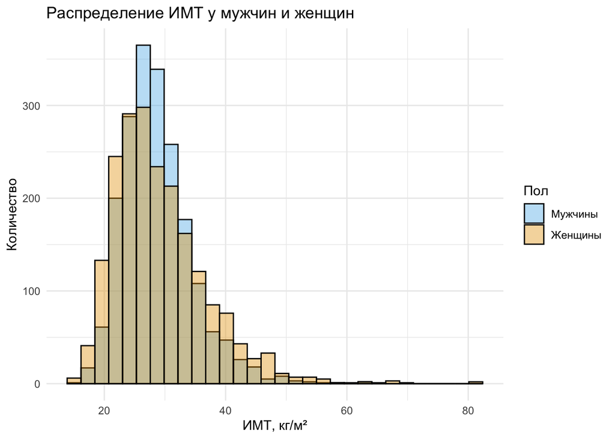

```r
ggplot(nhanes_clean, aes(x = BMI, fill = Gender)) +
  geom_histogram(color = "black", alpha = 0.4, position = "identity") +
  labs(
    title = "Распределение ИМТ у мужчин и женщин",
    x = "ИМТ, кг/м²",
    y = "Количество",
    fill = "Пол"
  ) +
  scale_fill_manual(
    values = c("female" = "#E69F00", "male" = "#56B4E9"),
    labels = c("female" = "Женщины", "male" = "Мужчины")
  ) +
  theme_minimal()
```

#### Задание 4.4

Проверьте гипотезы из задания 4.1 на уровне значимости α = 0.1.

```r
wilcox.test(BMI ~ Gender, data = nhanes_clean, conf.level = 0.9, conf.int = TRUE)
```

```
    Wilcoxon rank sum test with continuity correction

data:  BMI by Gender
W = 2054564, p-value = 0.534
alternative hypothesis: true location shift is not equal to 0
90 percent confidence interval:
 -0.1999960  0.4299661
sample estimates:
difference in location
             0.1100318
```

#### Задание 4.5

На основании полученного p-значения сделайте вывод о различии между группами. Что вы можете сказать про статистическую значимость?

В результате работы статистического теста мы получили p.value равно 0.534. Полученное значение выше заданного уровня значимости 0.1, таким образом мы не отвергаем нулевую гипотезу при заданном уровне значимости. У нас недостаточно оснований, чтобы сказать, что значения ИМТ у представителей одного пола выше, чем у представителей другого.

### 5. Сравнение систолического и диастолического давления

Вопрос исследования: превосходят ли, как правило, значения одного типа артериального давления значения другого типа (САД и ДАД)? САД – систолическое артериальное давление, ДАД – диастолическое артериальное давление.

#### Задание 5.1

Сформулируйте нулевую и альтернативную гипотезы.

- $H_0$: $Median[BPSysAve - BPDiaAve] = 0$
- $H_a$: $Median[BPSysAve - BPDiaAve] \neq 0$

#### Задание 5.2

Посчитайте ключевые статистики для переменных `BPSysAve` и `BPDiaAve` в вашем чистом наборе данных `nhanes_clean`. Обратите внимание, что это иные статистики, чем в задании 3.

```r
nhanes_clean |> summarise(
  across(
    .cols = c("BPSysAve", "BPDiaAve"),
    .fns = list(
      median = \(x) median(x),
      q1 = \(x) quantile(x, 0.25),
      q3 = \(x) quantile(x, 0.75),
      IQR = \(x) quantile(x, 0.75) - quantile(x, 0.25),
      n = \(x) n()
    ),
    .names = "{.col}_{.fn}"
    )
) |> pivot_longer(everything(), names_to = c(".value", "stat"), names_sep = "_") |> flextable()
```

| stat | BPSysAve | BPDiaAve |
| --- | --- | --- |
| median | 119 | 70 |
| q1 | 109 | 63 |
| q3 | 130 | 78 |
| IQR | 21 | 15 |
| n | 4,032 | 4,032 |

**Дополнительно (необязательное задание)** Визуализируйте эти параметры. Используйте скрипичный график и боксплот, свяжите линиями измерения одного пациента. Визуально оцените, как выглядит распределение обеих переменных.

#### Задание 5.3

Выберите подходящий статистический тест для проверки гипотез из задания 5.1 и объясните свой выбор.

Для ответа на поставленный исследовательский вопрос я воспользуюсь критерием Вилкоксона. Он подходит для данной задачи, так как показательные парные и соответствуют одним и тем же людям. С помощью него можно ответить на вопрос о превалировании одного показателя над другим у одного человека.

#### Задание 5.4

Используя выбранный тест, проверьте гипотезы из задания 5.1 на уровне значимости α = 0.1.

```r
wilcox.test(nhanes_clean$BPSysAve, nhanes_clean$BPDiaAve, paired = TRUE, conf.level = 0.9, conf.int = TRUE)
```

```
    Wilcoxon signed rank test with continuity correction

data:  nhanes_clean$BPSysAve and nhanes_clean$BPDiaAve
V = 8130528, p-value < 2.2e-16
alternative hypothesis: true location shift is not equal to 0
90 percent confidence interval:
 48.99998 49.50000
sample estimates:
(pseudo)median
      49.00002
```

#### Задание 5.5

На основании полученного p-значения сделайте вывод о различии между систолическим и диастолическим артериальным давлением. Что вы можете сказать про статистическую значимость?

В результате работы статистического теста мы получили p.value меньше 2.2e-16. Полученное значение меньше 0.1, тем самым мы можем отвергнуть нулевую гипотезу об отcутствии превалирования одного показателя над другим. Доминирование статистически значимо, систолическое давление систематически выше диастолического примерно на 49 мм рт. ст

# Тесты для категориальных данных

### 6. Поиск зависимости между физической активностью и проблемами со сном

Вы хотите исследовать, есть ли взаимосвязь между проблемами со сном у человека и тем, занимается ли он физической активностью. Переменные: `PhysActive` — бинарный признак (`Yes` = занимается физической активностью, `No` = не занимается), `SleepTrouble` — бинарный признак (`Yes` = есть проблемы со сном, `No` = нет проблем).

#### Задание 6.1

Сформулируйте нулевую и альтернативную гипотезы для проверки связи между физической активностью и проблемами со сном. Какую альтернативу вы используете – одностороннюю или двустороннюю? Обоснуйте ответ

- $H_0$: $P(SleepTrouble|PhysActive = Yes) = P(SleepTrouble|PhysActive = No)$
- $H_a$: $P(SleepTrouble|PhysActive = Yes) \neq P(SleepTrouble|PhysActive = No)$

Будем использовать двухстороннюю альтернативную гипотезу, так как в данном исследовании мы не отвечаем на вопрос о направлении взаимосвязи (оно не задано изначально)

#### Задание 6.2

Постройте таблицу сопряженности и визуализируйте ее. Исходя из полученной таблицы и иллюстрации, как вам кажется, похожи ли наши признаки на независимые? Почему?

```r
tab <- with(nhanes_clean, table(SleepTrouble, PhysActive))

prop_tab <- prop.table(tab, margin = 2)

tab
```

```
            PhysActive
SleepTrouble  Yes   No
         Yes  514  531
         No  1582 1405
```

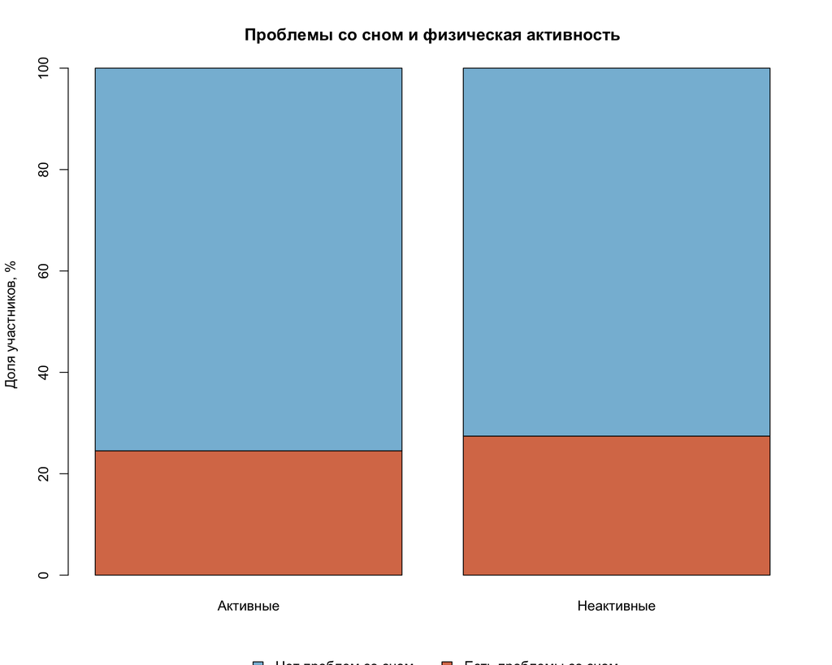

```r
barplot(100 * prop_tab,
col = c("#D97A56", "#86BBD8"),
names.arg = c("Активные", "Неактивные"),
legend.text = c("Есть проблемы со сном", "Нет проблем со сном"), ylab = "Доля участников, %", main = "Проблемы со сном и физическая активность",
args.legend = list(
  x = "bottom",
  inset = c(0, -0.2),
  horiz = TRUE,
  bty = "n"
))
```

Признаки похожи на независимые, доля людей с физической активностью и отсутствием проблем со сном близко к доле людей без физической активности и отсутствием проблем со сном.

#### Задание 6.3

Какой статистический тест подходит для тестирования гипотезы из задания 6.1 (Хи-квадрат, Фишер, МакНемара)? Объясните свой выбор. Какие ограничения у выбранного теста? Если нужно, проверьте ограничения.

Для ответа на этот исследовательский вопрос я буду использовать критерий Хи-квадрат, так как в ячейках таблицы отражено количеством участников с определенным сочетанием признаков. Наблюдения являются независимыми, поэтому мы не применяем критерий МакНемара для связных выборок. Ожидаемые частоты в ячейках превышают порог в 5 наблюдений (проверили с помощью правила Кохрана для ожидаемых частот).

```r
expected_freq <- chisq.test(tab)$expected
min(expected_freq)
```

```
[1] 501.7659
```

```r
expected_freq
```

```
            PhysActive
SleepTrouble       Yes        No
         Yes  543.2341  501.7659
         No  1552.7659 1434.2341
```

#### Задание 6.4

Используя выбранный тест, проверьте гипотезы из задания 6.1 на уровне значимости α = 0.05. Какое p-значение и значение статистики критерия получилось? Что вы можете сказать про статистическую значимость?

Совпадает ли результат статистического анализа с вашим предположением в задании 6.2? Если нет, попробуйте объяснить почему.

```r
alpha <- 0.05
chi_result <- chisq.test(tab)
chi_result$p.value < alpha
```

```
[1] TRUE
```

```r
chi_result
```

```
    Pearson's Chi-squared test with Yates' continuity correction

data:  tab
X-squared = 4.2728, df = 1, p-value = 0.03873
```

В результате работы теста мы получили p.value равное 0.03873. Полученное p.value меньше заданного уровня значимости, разультат статистически значимый и мы можем отвергнуть нулевую гипотезу о независимости признаков.

Полученный результат не соответствует моим предоположениям о независимости признаков. Возможно из-за большого размера выборки тест обладает высокой статистической мощностью, по причине чего может уловить даже минимальные различия.

#### Задание 6.5

Посчитайте размер эффекта (отношение шансов и отношение рисков, если это имеет смысл для этого исследования) двумя способами – самостоятельно (посчитайте дроби исходя из таблицы сопряженности), и с помощью пакета epitools, сравните результаты. Проинтерпретируйте результат с точки зрения клинической значимости (не забудьте про 95% доверительный интервал!). Прокомментируйте, почему вы решили считать или не считать отношение рисков.

```r
library(epitools)

a <- tab["Yes", "Yes"] #активные с проблемой со сном
b <- tab["Yes", "No"] #активные без проблем со сном
c <- tab["No", "Yes"] #неактивные с проблемами со сном
d <- tab["No", "No"] #неактивные без проблем со сном

or <- (a / b) / (c / d)

or_epi <- oddsratio(tab, conf.level = 0.95)$measure

or
```

```
[1] 0.8596832
```

```r
or_epi
```

```
            odds ratio with 95% C.I.
SleepTrouble  estimate     lower     upper
         Yes 1.0000000        NA        NA
         No  0.8597353 0.7466163 0.9898888
```

```r
prop_tab
```

```
            PhysActive
SleepTrouble       Yes        No
         Yes 0.2452290 0.2742769
         No  0.7547710 0.7257231
```

Посчитанные отношения шансов равны (значение, которое посчитано вручную близко к значению, посчитанному с помощью epitools). Отношение шансов равно ~0,86, это значит, что в выборке у активных участников шансы сообщить о проблемах со сном ниже примено на 14%, чем у неактивных участников. 95% доверительный интервал для отношения шансов у активных по сравнению с неактивными лежит ниже 1, это значит, что связь статистически значима на уровне значимости 0.05.

Однако, если мы найдем разность между процентом активных участников с проблемой со сном и неактивных участников с проблемой со сном 24,52% - 27,43% = -2.91%, это примерно на 3 человека больше на каждые 100 в неактивной группе, это вызывает вопросы с точки зрения клинической значимости.

Отношение рисков не было посчитано, так как в поперечном исследовании неизвестно, у кого проблемы со сном возникли за определенный период.

#### Задание 6.6

Исходя из результатов статистического анализа, можем ли мы сделать вывод, что физическая активность улучшает сон? Или что люди, которые лучше спят, чаще занимаются спортом?

По результатам статистического анализа мы можем прийти к выводу, что между физической активностью и проблемами со сном есть статистически значимая связь. Физически активные участники реже сообщали о проблемах со сном. Однако, по данным этого исследования у нас недостаточно оснований утверждать, что физическая активность улучшает сон или что хороший сон способствует физической активности.

# Поиск зависимостей между количественными / порядковыми признаками

### 7. Анализ зависимости между ростом и массой тела

Вопрос исследования: есть ли линейная связь между ростом (`Height`) и массой тела (`Weight`) у участников NHANES в возрасте 18 лет и старше?

#### Задание 7.1

Сформулируйте нулевую и альтернативную гипотезы.

- $H_0$: У взрослых участников NHANES линейная корреляция между ростом и массой тела равна нулю $\rho = 0$
- $H_a$: У взрослых участников NHANES линейная корреляция между ростом и массой тела не равна нулю $\rho \neq 0$

#### Задание 7.2

Визуализируйте распределения анализируемых переменных. Визуально оцените форму распределений и наличие выбросов.

Постройте диаграмму рассеяния роста (`Height`) и массы тела (`Weight`) (график должен быть читаемым), оцените линейность связи признаков.

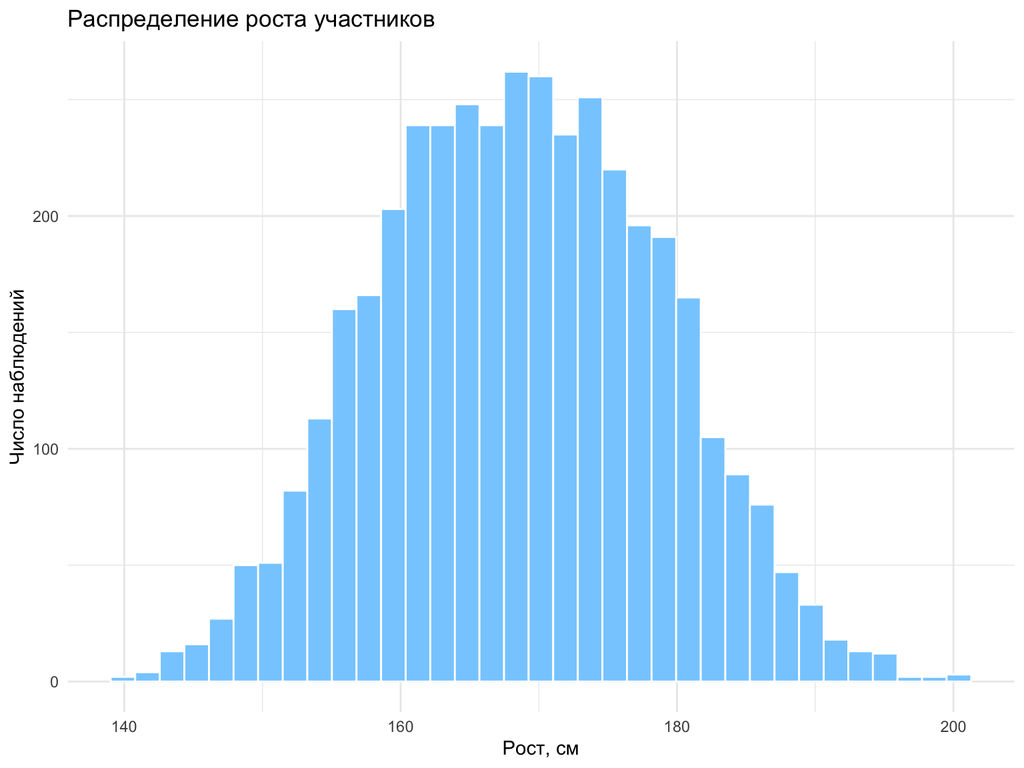

```r
ggplot(nhanes_clean, aes(x = Height)) +
  geom_histogram(bins = 35, color = "white", fill = "skyblue1") +
  labs(title = "Распределение роста участников",
  x = "Рост, см", y = "Число наблюдений") +
  theme_minimal()
```

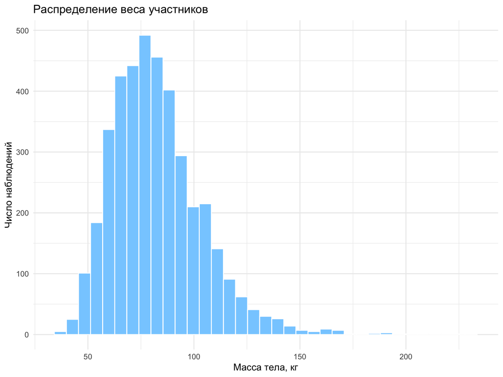

```r
ggplot(nhanes_clean, aes(x = Weight)) +
  geom_histogram(bins = 35, color = "white", fill = "skyblue1") +
  labs(title = "Распределение веса участников",
  x = "Масса тела, кг", y = "Число наблюдений") +
  theme_minimal()
```

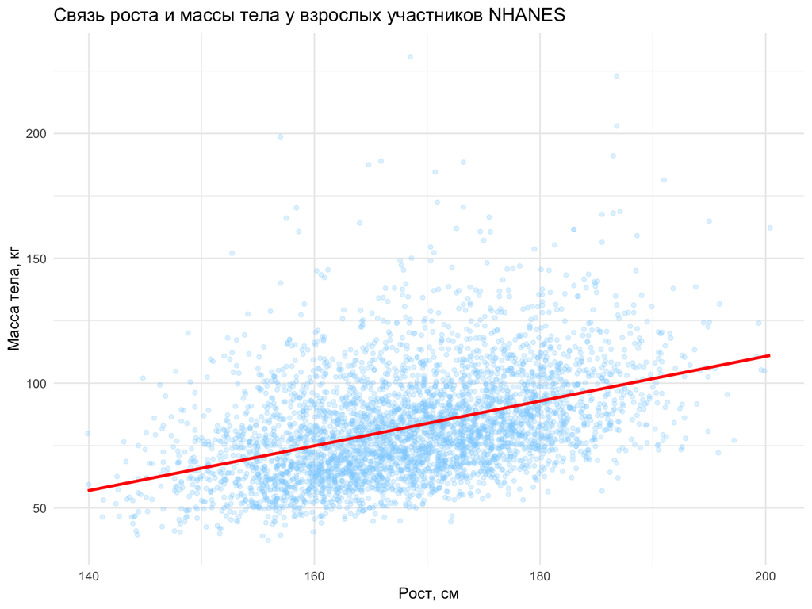

```r
ggplot(nhanes_clean, aes(x = Height, y = Weight)) +
  geom_point(alpha = 0.25, size = 1.2, color = "skyblue1") +
  geom_smooth(method = "lm", formula = y ~ x, se = FALSE, color = "red") +
  labs(title = "Связь роста и массы тела у взрослых участников NHANES",
       x = "Рост, см", y = "Масса тела, кг") +
  theme_minimal()
```

#### Задание 7.3

Выберите подходящий статистический тест для проверки гипотезы из задания 7.1 и объясните свой выбор.

Используя выбранный тест, проверьте гипотезы из задания 7.1 на уровне значимости α = 0.05.

Оцените величину наблюдаемого эффекта.

```r
hw <- cor.test(
  nhanes_clean$Height, nhanes_clean$Weight,
  method = "pearson", alternative = "two.sided", conf.level = 0.95
)

hw
```

```
    Pearson's product-moment correlation

data:  nhanes_clean$Height and nhanes_clean$Weight
t = 29.761, df = 4030, p-value < 2.2e-16
alternative hypothesis: true correlation is not equal to 0
95 percent confidence interval:
 0.3988381 0.4494593
sample estimates:
      cor
0.4244803
```

Для проверки гипотезы я использовала двусторонний тест корреляции Пирсона, так как рост и масса тела являются количественными признаками, а вопрос исследования касается линейной связи. Величину и направление наблюдаемой связи я оценила по выборочному коэффициенту корреляции.

#### Задание 7.4

Как p-значение и 95% доверительный интервал информируют вас о силе и направлении связи между ростом и весом? Что вы можете сказать про статистическую и практическую значимость результата?

В результате работы теста мы получили коэффициент корреляции Пирсона равный 0.4244803 с 95% доверительным интервалом (0.3988381-0.4494593) и p.value < 2.2e-16. Полученное p.value меньше уровня значимости 0.05, поэтому мы может отвергнуть нулевую гипотезу об отсутствии линейной связи. Обе границы доверительного интервала выше 0, это указывает на умеренно положительную линейную связь: у более высоких участников в среднем масса тела больше. Однако, важно учитывать разброс на диаграмме рассеяния, на ней мы можем увидеть, что у участников одного роста может заметно различаться масса тела.

### 8. Анализ зависимости между образованием и доходом

Вопрос исследования: существует ли связь между уровнем образования (`Education`) и доходом домохозяйства (`HHIncome`) у участников NHANES в возрасте 18 лет и старше?

#### Задание 8.1

Сформулируйте нулевую и альтернативную гипотезы.

- $H_0$: Корреляция между уровнем образования и категорией дохода домохозяйства равна 0, $\rho = 0$
- $H_a$: Корреляция между уровнем образования и категорией дохода домохозяйства не равна 0, $\rho \neq 0$

#### Задание 8.2

Постройте диаграмму рассеяния, которая позволит визуализировать связь между изучаемыми переменными.

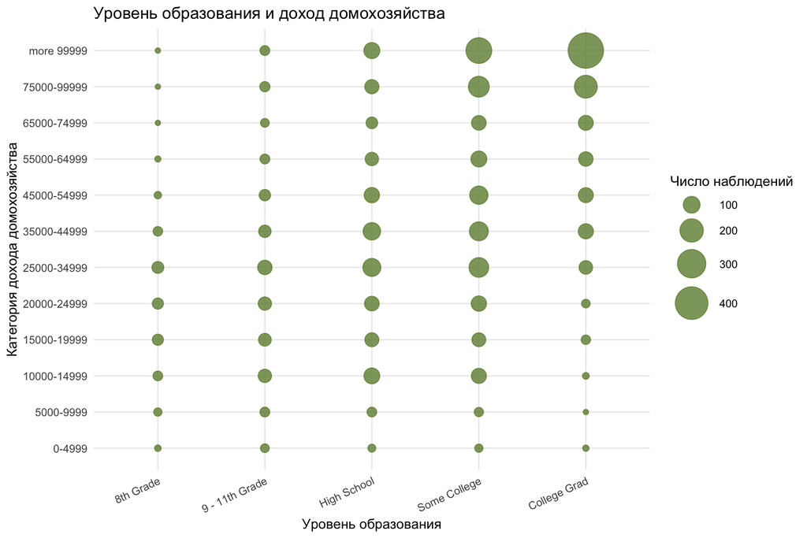

```r
ggplot(nhanes_clean, aes(x = Education, y = HHIncome)) +
  geom_count(color = "darkolivegreen4", alpha = 0.8) +
  scale_size_area(max_size = 13, name = "Число наблюдений") +
  labs(title = "Уровень образования и доход домохозяйства", x = "Уровень образования", y = "Категория дохода домохозяйства") +
  theme_minimal() +
  theme(axis.text.x = element_text(angle = 25, hjust = 1))
```

На графике видна положительная связь между уровнем образования и доходом домохозяйства. Среди выпускников колледжа чаще встречается категория дохода больше 99 999 долларов, а среди участников с образованием до 8-го класса включительно эта категория встречается очень редко. Несмотря на это, в каждой категории образования предствалены все уровни дохода.

#### Задание 8.3

Выберите подходящий статистический тест для проверки гипотезы из задания 8.1 и объясните свой выбор.

Используя выбранный тест, проверьте гипотезы из задания 8.1 на уровне значимости α = 0.05.

Оцените величину наблюдаемого эффекта.

```r
education <- as.integer(nhanes_clean$Education)
income <- as.integer(nhanes_clean$HHIncome)

spearman <- cor.test(
  education, income,
  method = "spearman", alternative = "two.sided", exact = FALSE
)

spearman
```

```
    Spearman's rank correlation rho

data:  education and income
S = 6087144201, p-value < 2.2e-16
alternative hypothesis: true rho is not equal to 0
sample estimates:
    rho
0.44281
```

Я использовала двусторонний тест корреляции Спирмена, так как образование и доход представлены упорядоченными категориями. Для этого теста достаточно знать порядок категорий. С помощью этого теста мы можем оценить, имеют ли участники с более высоким образованием тендецию попадать в более высокие или низкие категории дохода.

#### Задание 8.4

Как p-значение и значение коэффициента корреляции информируют вас о силе и направлении связи между уровнем образования и доходом домохозяйства? Что вы можете сказать про статистическую и практическую значимость результата?

В результате работы теста мы получили коэффициент корреляции Спирмена равный 0.44281 и p.value < 2.2e-16. Полученное p.value меньше уровня значимости 0.05, поэтому мы можем отвергнуть нулевую гипотезу о равенстве связи нулю. В выборке связь умеренно положительная, cor > 0: участники с более высоким уровнем образования, как правило, относятся к более высоким уровням дохода, в то время как участники с более низким уровнем образования, как правило, относятся к более низким категориям дохода. Для оценки практической значимости важно учитывать величину коэффициента и разброс точек на графике. Даже при статистически значимой корреляции у участников с одинаковым уровнем образования могут существенно различаться доходы домохозяйств.